# Final Project Basic Outline

Mia and Madeline

# Research Question

Our project delves into the question of whether there is a correlation between climate and human population movement. When looking at reasons why people choose to live in certain locations, it is important to consider all contributing factors. To represent the *climate* factor in this data exploration will be ‘**sunshine**’ and ‘**latitude**’ related variables. To represent *human population movement* there will be ‘**tourism**’ and ‘**population**’ related variables.  
Seasonal depression and mood-changes due to weather and climate patterns can have a serious impact on peoples’ lives. Applying this knowledge, climate could be associated with certain locations having increased populations or tourism traffic.

# Data Processing

### Loading in Basic Packages

```r
library(tidyverse)
library(dplyr)
```

## Climate Data

### Sunshine Hours

```r
sunshine <- read.csv(file = 'Sunshine hours for cities in the world.csv') # import csv in df
str(sunshine)
```

```
'data.frame':   392 obs. of  15 variables:
 $ Country: chr  "Ivory Coast" "Ivory Coast" "Ivory Coast" "Ivory Coast" ...
 $ City   : chr  "Gagnoa" "Bouaké" "Abidjan" "Odienné" ...
 $ Jan    : num  183 242 223 242 279 ...
 $ Feb    : num  180 224 223 220 249 ...
 $ Mar    : num  196 219 239 217 253 ...
 $ Apr    : num  188 194 214 215 229 ...
 $ May    : num  181 208 205 249 251 ...
 $ Jun    : num  118 145 128 222 221 ...
 $ Jul    : num  97 104 137 184 183 ...
 $ Aug    : num  80 82 125 174 151 ...
 $ Sep    : num  110 115 139 185 173 ...
 $ Oct    : num  155 170 215 236 245 ...
 $ Nov    : num  171 191 224 252 261 243 252 282 234 284 ...
 $ Dec    : num  164 198 224 243 262 ...
 $ Year   : num  1823 2092 2296 2639 2757 ...
```

```r
sample_n(sunshine, 10)
```

| Country | City | Jan | Feb | Mar | Apr | May | Jun | Jul | Aug | Sep | Oct | Nov | Dec | Year |
| --- | --- | --- | --- | --- | --- | --- | --- | --- | --- | --- | --- | --- | --- | --- |
| United States | Indianapolis | 132.1 | 145.7 | 178.3 | 214.8 | 264.7 | 287.2 | 295.2 | 273.7 | 232.6 | 196.6 | 117.1 | 102.4 | 2440.4 |
| Gabon | Libreville | 175.2 | 176.8 | 176.9 | 176.8 | 159.5 | 130.6 | 119.2 | 90.4 | 95.9 | 112.9 | 134.6 | 167.8 | 1716.6 |
| Ivory Coast | Odienné | 242.0 | 220.2 | 217.3 | 214.7 | 248.8 | 221.8 | 183.5 | 174.5 | 185.4 | 235.8 | 252.0 | 242.6 | 2638.6 |
| Canada | Winnipeg | 114.7 | 133.9 | 181.9 | 241.4 | 285.3 | 276.3 | 308.3 | 281.4 | 189.0 | 147.4 | 93.9 | 99.5 | 2352.9 |
| India | Bangalore | 262.0 | 248.0 | 271.0 | 257.0 | 241.0 | 137.0 | 112.0 | 114.0 | 144.0 | 173.0 | 190.0 | 212.0 | 2361.0 |
| India | Chennai | 232.5 | 240.1 | 291.4 | 294.0 | 300.7 | 234.0 | 142.6 | 189.1 | 195.0 | 257.3 | 261.0 | 210.8 | 2848.5 |
| Mauritania | Nouakchott | 267.0 | 250.0 | 302.0 | 311.0 | 320.0 | 284.0 | 271.0 | 265.0 | 266.0 | 263.0 | 268.0 | 267.0 | 3333.0 |
| Turkey | Ankara | 77.5 | 98.9 | 161.2 | 189.0 | 260.4 | 306.0 | 350.3 | 328.6 | 276.0 | 198.4 | 132.0 | 71.3 | 2449.6 |
| Senegal | Dakar | 253.0 | 249.0 | 303.0 | 301.0 | 299.0 | 259.0 | 233.0 | 204.0 | 219.0 | 254.0 | 256.0 | 249.0 | 3078.0 |
| Indonesia | Jakarta | 189.1 | 180.8 | 238.7 | 255.0 | 260.4 | 255.0 | 282.1 | 294.5 | 300.7 | 279.0 | 231.0 | 217.0 | 2983.3 |

- The *sunshine* data has 392 cases of individual cities across the world and the total number of sunshine hours they get per month. The data also contains the country each city resides in and the total number of hours of sunshine per year.
- This data was found on Kaggle (https://www.kaggle.com/datasets/bilalwaseer/sunshine-hours-for-cities-around-the-world) and was published by *Muhammad Bilal Hussain* at the beggining of 2023.

### Latitude/Longitude

- The original data set was too big for GitHub, so the data had to be processed and wrangled in a separate RScript, then saved into a new csv file and imported into this file. Images of the coding work are included.

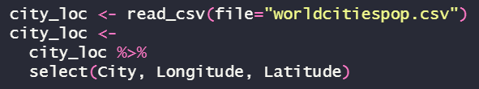

- This data set is the already wrangled version (image of the wrangling done below in *Data Wrangling* section).
- Data was found on Kaggle (https://www.kaggle.com/datasets/max-mind/world-cities-database) and was posted by *Max Mind*.

```r
city_loc <- read_csv(file="city_loc.csv") # import csv in df
str(city_loc)
```

```
spc_tbl_ [7,420 × 4] (S3: spec_tbl_df/tbl_df/tbl/data.frame)
 $ ...1     : num [1:7420] 1 2 3 4 5 6 7 8 9 10 ...
 $ City     : chr [1:7420] "tokyo" "tokyo" "delhi" "delhi" ...
 $ Longitude: num [1:7420] 139.8 147.2 -80.5 97.4 77.2 ...
 $ Latitude : num [1:7420] 35.7 -8.4 42.9 37.4 28.7 ...
 - attr(*, "spec")=
  .. cols(
  ..   ...1 = col_double(),
  ..   City = col_character(),
  ..   Longitude = col_double(),
  ..   Latitude = col_double()
  .. )
 - attr(*, "problems")=<externalptr>
```

```r
sample_n(city_loc, 10)
```

| ...1 | City | Longitude | Latitude |
| --- | --- | --- | --- |
| 2654 | valencia | -76.40373 | 4.934532 |
| 1525 | santo domingo | -89.30611 | 16.240556 |
| 4797 | copenhagen | 26.75299 | -30.048811 |
| 4413 | san jose | -73.02392 | 6.033607 |
| 802 | barcelona | -80.70000 | -1.950000 |
| 1752 | lusaka | 25.31667 | -6.966667 |
| 5625 | cartagena | 122.40040 | 9.820300 |
| 6732 | concepcion | -98.25000 | 19.050000 |
| 6637 | la plata | -98.63472 | 25.909722 |
| 6350 | san jose | -100.76667 | 22.316667 |

## Population Data

### Country Tourism

- Another way to represent the correlation between climate and human population movement, is looking at a locations climate and tourism rates.
- This data measures the amount of tourism dollars spent in different countries over the course of selected years (in US dollars).
- Dataset was found on Kaggle (https://www.kaggle.com/datasets/abdulhamitcelik/international-tourism-receipts) and was posted by *Abdulhamit Celik*.

```r
country_tour <- read.csv("tourism-recipts.csv") # import csv in df
str(country_tour)
```

```
'data.frame':   4156 obs. of  4 variables:
 $ name   : chr  "Afghanistan" "Afghanistan" "Afghanistan" "Afghanistan" ...
 $ code   : chr  "AFG" "AFG" "AFG" "AFG" ...
 $ year   : int  2008 2009 2010 2011 2012 2013 2014 2015 2016 2017 ...
 $ value_.: num  5.70e+07 8.90e+07 1.47e+08 1.65e+08 1.67e+08 1.79e+08 1.21e+08 8.60e+07 6.20e+07 1.60e+07 ...
```

```r
sample_n(country_tour, 10)
```

| name | code | year | value_. |
| --- | --- | --- | --- |
| Bulgaria | BGR | 1997 | 5.1700e+08 |
| Aruba | ABW | 2003 | 8.5810e+08 |
| Malaysia | MYS | 1995 | 5.0440e+09 |
| Syrian Arab Republic | SYR | 2007 | 2.9720e+09 |
| Chile | CHL | 2019 | 3.2790e+09 |
| Brazil | BRA | 1996 | 7.4400e+08 |
| Chile | CHL | 2018 | 3.9110e+09 |
| Poland | POL | 2017 | 1.3925e+10 |
| Romania | ROU | 2013 | 2.3070e+09 |
| Honduras | HND | 2001 | 2.6000e+08 |

### City Population

- This data set contains city and country name as well as the population of 2022, 2023, growth rate, type (world versus USA), and rank (1 being the most populated city, 778 being the least populated).
- This table will be used to see the correlation between the amount of sunshine a city gets and its population. The ‘*growth rate*’ of the population will be used to more accurately evaluate population changes regardless of a locations size.
- This data was found on World Population Review (https://worldpopulationreview.com/world-cities).

```r
CityPopulations <- read_csv(file = "world-city-listing.csv") # import csv in df
str(CityPopulations)
```

```
spc_tbl_ [778 × 7] (S3: spec_tbl_df/tbl_df/tbl/data.frame)
 $ pop2023   : num [1:778] 37194104 32941308 29210808 23209616 22619736 ...
 $ pop2022   : num [1:778] 37274000 32065760 28516904 22478116 22429800 ...
 $ city      : chr [1:778] "Tokyo" "Delhi" "Shanghai" "Dhaka" ...
 $ country   : chr [1:778] "Japan" "India" "China" "Bangladesh" ...
 $ growthRate: num [1:778] -0.0021 0.0273 0.0243 0.0325 0.0085 0.0089 0.0199 0.0203 0.016 -0.0024 ...
 $ type      : chr [1:778] "w" "w" "w" "w" ...
 $ rank      : chr [1:778] "1" "2" "3" "4" ...
 - attr(*, "spec")=
  .. cols(
  ..   pop2023 = col_double(),
  ..   pop2022 = col_double(),
  ..   city = col_character(),
  ..   country = col_character(),
  ..   growthRate = col_double(),
  ..   type = col_character(),
  ..   rank = col_character()
  .. )
 - attr(*, "problems")=<externalptr>
```

```r
sample_n(CityPopulations, 10)
```

| pop2023 | pop2022 | city | country | growthRate | type | rank |
| --- | --- | --- | --- | --- | --- | --- |
| 1248783 | 1190367 | Bukavu | DR Congo | 0.0491 | w | 452 |
| 3839646 | 3652029 | Abuja | Nigeria | 0.0514 | w | 124 |
| 1213348 | 1197931 | Chiang Mai | Thailand | 0.0129 | w | 471 |
| 757224 | 737464 | Yanji | China | 0.0268 | w | 770 |
| 1413474 | 1389302 | Queretaro | Mexico | 0.0174 | w | 382 |
| 2603243 | 2573758 | Tashkent | Uzbekistan | 0.0115 | w | 196 |
| 1461989 | 1441324 | San Jose | Costa Rica | 0.0143 | w | 364 |
| 1421052 | 1423343 | Kharkiv | Ukraine | -0.0016 | w | 380 |
| 1314178 | 1277242 | Tanger | Morocco | 0.0289 | w | 417 |
| 1689499 | 1667187 | Anshan | China | 0.0134 | w | 309 |

# Data Wrangling

## Climate Data

### Sunshine Hours

- The original data *sunshine* is already pretty clean data and did not need much wrangling on its own, however there is data we can manipulate for later usage.
- I created *sunshine_seasons* which contains the total number of hours for (roughly) each season. Technically seasons tend the start in the middle of a month, so I had to do come approximation on how I split the seasons up.

```r
sunshine_seasons <-
  sunshine %>%
  mutate(Winter=Jan+Feb+Mar, Spring=Apr+May+Jun, Summer=Jul+Aug+Sep, Fall=Oct+Nov+Dec) %>%# create new variables to represent each season
  mutate(City=tolower(City)) # change city names to lower case for joining later on
sample_n(sunshine_seasons, 10)
```

| Country | City | Jan | Feb | Mar | Apr | May | Jun | Jul | Aug | Sep | Oct | Nov | Dec | Year | Winter | Spring | Summer | Fall |
| --- | --- | --- | --- | --- | --- | --- | --- | --- | --- | --- | --- | --- | --- | --- | --- | --- | --- | --- |
| Denmark | aarhus | 54.0 | 72.0 | 148.0 | 213.0 | 260.0 | 251.0 | 242.0 | 211.0 | 161.0 | 101.0 | 60.0 | 49.0 | 1821.0 | 274.0 | 724.0 | 614.0 | 210.0 |
| Spain | madrid | 148.0 | 157.0 | 214.0 | 231.0 | 272.0 | 310.0 | 359.0 | 335.0 | 261.0 | 198.0 | 157.0 | 124.0 | 2769.0 | 519.0 | 813.0 | 955.0 | 479.0 |
| Brazil | salvador | 246.9 | 215.0 | 227.2 | 194.1 | 165.8 | 147.8 | 169.1 | 189.1 | 211.4 | 235.5 | 210.9 | 230.2 | 2443.0 | 689.1 | 507.7 | 569.6 | 676.6 |
| Papua New Guinea | port moresby | 182.0 | 158.0 | 184.0 | 200.0 | 211.0 | 200.0 | 203.0 | 222.0 | 213.0 | 231.0 | 243.0 | 216.0 | 2463.0 | 524.0 | 611.0 | 638.0 | 690.0 |
| South Africa | johannesburg | 250.1 | 224.8 | 238.8 | 236.9 | 276.0 | 266.9 | 283.9 | 284.1 | 280.8 | 269.5 | 248.7 | 263.9 | 3124.4 | 713.7 | 779.8 | 848.8 | 782.1 |
| Netherlands | amsterdam | 63.0 | 88.0 | 126.0 | 183.0 | 222.0 | 206.0 | 217.0 | 197.0 | 139.0 | 109.0 | 62.0 | 51.0 | 1662.0 | 277.0 | 611.0 | 553.0 | 222.0 |
| South Korea | seoul | 160.3 | 163.3 | 189.0 | 205.0 | 213.0 | 182.0 | 120.0 | 152.5 | 176.2 | 198.8 | 153.2 | 152.6 | 2066.0 | 512.6 | 600.0 | 448.7 | 504.6 |
| China | ürümqi | 101.6 | 128.8 | 180.5 | 248.0 | 283.3 | 282.7 | 298.7 | 301.0 | 262.6 | 224.4 | 127.4 | 84.3 | 2523.3 | 410.9 | 814.0 | 862.3 | 436.1 |
| United States | cleveland | 101.0 | 122.3 | 167.0 | 216.0 | 263.6 | 294.6 | 307.2 | 262.2 | 219.0 | 169.5 | 89.8 | 67.8 | 2280.0 | 390.3 | 774.2 | 788.4 | 327.1 |
| Nigeria | jos | 307.0 | 274.0 | 260.0 | 220.0 | 208.0 | 201.0 | 151.0 | 127.0 | 171.0 | 242.0 | 294.0 | 313.0 | 2768.0 | 841.0 | 629.0 | 449.0 | 849.0 |

### Latitude/Longitude

- This data contains a lot of information that is not needed for our purposes: there are extraneous variables and cases that are duplicated to makeup for different spellings of cities. To eliminate this extra data, I will use **select()** to keep only the columns we need and join the table with the *CityPopulations1* cities to only keep the cities we need.

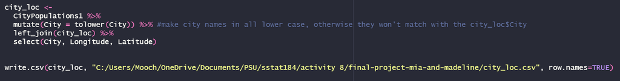

- Although the tables are now joined, the *city_loc* data contained multiple locations for many of the cities, presumably to represent different corners of each. To combat this, I will take the average of the longitude and latitude for each city and use the new numbers as the primary location for each city.

```r
city_loc <-
  city_loc %>%
  group_by(City) %>%
  mutate(Longitude = mean(Longitude), Latitude = mean(Latitude)) %>% # get the average location
  select(City, Longitude, Latitude) %>%
  distinct() # remove repeated cities, so each city appears one time
```

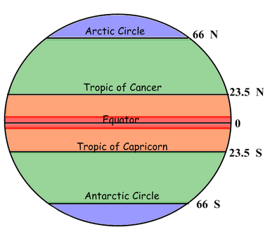

- In the graphic the lines for different latitude subsections are shown. I will be using these to split up countries. *tropical* is anywhere from lat -23.5 to 23.5, *moderate* is from -23.5 to -66 and 23.5 to 66 and *poles* will be the rest.

```r
city_loc <-
  city_loc %>%
  na.omit()

for(i in 1:length(city_loc$Latitude)){ # loop through each case in Latitude variable
  if((city_loc$Latitude[i]>=(-23.5)) && (city_loc$Latitude[i]<=23.5)){ # calssify variables by 'Latitude'
    city_loc$climate[i] = "tropical"
    }
  else if(city_loc$Latitude[i]>=(-66) && city_loc$Latitude[i]<(-23.5) || city_loc$Latitude[i]<=(66) && city_loc$Latitude[i]>(23.5)){
    city_loc$climate[i] = "moderate"
    }
  else city_loc$climate[i] = "poles"
}
city_loc
```

| City | Longitude | Latitude | climate |
| --- | --- | --- | --- |
| tokyo | 1.434507e+02 | 13.6425000 | tropical |
| delhi | -6.864060e+01 | 37.3943817 | moderate |
| shanghai | -1.194506e+01 | 33.8458448 | moderate |
| dhaka | 7.871130e+01 | 29.2888686 | moderate |
| sao paulo | -2.960778e+01 | -7.3404734 | tropical |
| cairo | -7.847850e+01 | 31.4051381 | moderate |
| beijing | 1.168079e+02 | 36.0917497 | moderate |
| mumbai | 7.282583e+01 | 18.9750000 | tropical |
| osaka | 2.737646e+01 | 37.7438194 | moderate |
| chongqing | 1.168433e+02 | 37.7215345 | moderate |

[output cut: 702 more lines]

### Climate

- For ease later on, select variables from **sunshine_seasons** and **city_loc** will be added into a single **climate** data frame.

```r
climate <-
  city_loc %>%
  left_join(sunshine_seasons) %>%# join the tables by 'City'
  na.omit() # remove cities with missing data
head(climate)
```

| City | Longitude | Latitude | climate | Country | Jan | Feb | Mar | Apr | May | Jun | Jul | Aug | Sep | Oct | Nov | Dec | Year | Winter | Spring | Summer | Fall |
| --- | --- | --- | --- | --- | --- | --- | --- | --- | --- | --- | --- | --- | --- | --- | --- | --- | --- | --- | --- | --- | --- |
| tokyo | 143.45069 | 13.64250 | tropical | Japan | 184.5 | 165.8 | 163.1 | 176.9 | 167.8 | 125.4 | 146.4 | 169.0 | 120.9 | 131.0 | 147.9 | 178.0 | 1876.7 | 513.4 | 470.1 | 436.3 | 456.9 |
| delhi | -68.64060 | 37.39438 | moderate | India | 214.6 | 216.1 | 239.1 | 261.0 | 263.1 | 196.5 | 165.9 | 177.0 | 219.0 | 269.3 | 247.2 | 215.8 | 2684.6 | 669.8 | 720.6 | 561.9 | 732.3 |
| shanghai | -11.94506 | 33.84584 | moderate | China | 114.3 | 119.9 | 128.5 | 148.5 | 169.8 | 130.9 | 190.8 | 185.7 | 167.5 | 161.4 | 131.1 | 127.4 | 1775.8 | 362.7 | 449.2 | 544.0 | 419.9 |
| dhaka | 78.71130 | 29.28887 | moderate | Bangladesh | 279.0 | 226.0 | 217.0 | 180.0 | 155.0 | 90.0 | 62.0 | 62.0 | 90.0 | 186.0 | 240.0 | 279.0 | 2066.0 | 722.0 | 425.0 | 214.0 | 705.0 |
| cairo | -78.47850 | 31.40514 | moderate | Egypt | 229.4 | 234.9 | 279.0 | 306.0 | 331.7 | 363.0 | 372.0 | 356.5 | 318.0 | 294.5 | 246.0 | 210.8 | 3541.8 | 743.3 | 1000.7 | 1046.5 | 751.3 |
| beijing | 116.80795 | 36.09175 | moderate | China | 194.1 | 194.7 | 231.8 | 251.9 | 283.4 | 261.4 | 212.4 | 220.9 | 232.1 | 222.1 | 185.3 | 180.7 | 2670.8 | 620.6 | 796.7 | 665.4 | 588.1 |

# Population Data

### Tourism

- After in taking the data, some things that need adjustment in the data: pick only one year to use for the tourism income (to cut down on the data), rename the variables, get rid of the country codes and divide the values into smaller numbers, since they are quite large.

```r
country_tour <-
  country_tour %>%
  rename(income='value_.') %>%
  select(name, year, income)
```

- In order to find the most useful year, I am going to **group_by()** year and find a year that is relatively recent (>=2015) and contains the most countries with data for that year.

```r
country_tour %>%
  filter(year >= 2015) %>%
  group_by(year) %>%
  summarise(num_of_countries = n()) #count the number of countries with data for each year
```

| year | num_of_countries |
| --- | --- |
| 2015 | 171 |
| 2016 | 172 |
| 2017 | 167 |
| 2018 | 164 |
| 2019 | 141 |
| 2020 | 129 |

- From here, we can see the most useful year for these purposes will be 2016. Now the *country_tour* can be shrunk down.

```r
country_tour <-
  country_tour %>%
  filter(year == 2016) %>% # only retain cases from 2016
  mutate(income = as.integer(income/100000)) %>% # divide income by 100,000 for easier reading/plotting
  rename("tourism income (by 100,000)" = income, Country=name) %>% # rename variables for readability
  select(Country, 'tourism income (by 100,000)') # get rid of year variable since all data is from 2016
sample_n(country_tour,10)
```

| Country | tourism income (by 100,000) |
| --- | --- |
| Kenya | 14720 |
| Grenada | 4370 |
| Bulgaria | 41480 |
| Russian Federation | 128220 |
| Uzbekistan | 5790 |
| United Arab Emirates | 286574 |
| Maldives | 26400 |
| Cayman Islands | 7080 |
| Bahrain | 40210 |
| Oman | 23240 |

- After dividing the income by $100,000 and renaming the variable, this data is ready for use.

### City Population Data

- This data just needed brief cleaning.

```r
CityPopulations1 <-
  CityPopulations %>%
  rename(Country = country, City = city, GrowthRate = growthRate) %>% # renaming variables for usability
  select(Country, GrowthRate) # choosing relevant variables
sample_n(CityPopulations1,10)
```

| Country | GrowthRate |
| --- | --- |
| China | 0.0301 |
| Costa Rica | 0.0143 |
| Mexico | 0.0135 |
| Ghana | 0.0210 |
| China | 0.0243 |
| China | 0.0141 |
| Germany | 0.0009 |
| Argentina | 0.0129 |
| India | 0.0257 |
| Turkey | 0.0165 |

### Population

- **tourism** and **population growth** will be combined into one table named **Population**.

```r
population <-
  CityPopulations1 %>%
  left_join(country_tour) %>% # join the tables by Country
  na.omit() # remove cases with missing data
head(population)
```

| Country | GrowthRate | tourism income (by 100,000) |
| --- | --- | --- |
| Japan | -0.0021 | 334560 |
| India | 0.0273 | 231110 |
| Bangladesh | 0.0325 | 2143 |
| Brazil | 0.0085 | 66130 |
| Mexico | 0.0089 | 206190 |
| Egypt | 0.0199 | 33060 |

- This table does not clearly show any correlation between climate and the amount of tourism income a country gets.

```r
# create a new variable to contain the different increments of tourism income
for(i in 1:nrow(population)){
  if(population$'tourism income (by 100,000)'[i]<5000){population$tour_group[i]="<5000"}
  else if(population$'tourism income (by 100,000)'[i]<10000){population$tour_group[i]="<10000"}
  else if(population$'tourism income (by 100,000)'[i]<20000){population$tour_group[i]="<20000"}
  else if(population$'tourism income (by 100,000)'[i]<50000){population$tour_group[i]="<50000"}
  else if(population$'tourism income (by 100,000)'[i]<100000){population$tour_group[i]="<100000"}
  else{population$tour_group[i]=">100000"}
}
# count the number of countries with different tourism incomes grouped by climate region.
population %>%
  select(Country, tour_group) %>%
  unique() %>%
  left_join(climate) %>%
  select(Country, tour_group, climate) %>%
  group_by(tour_group, climate) %>%
  summarise(total=n()) %>%
  na.omit() %>%
  pivot_wider(values_from=total, names_from=climate)
```

| tour_group | moderate | tropical |
| --- | --- | --- |
| <10000 | 4 | 5 |
| <100000 | 11 | 18 |
| <20000 | 4 | 10 |
| <5000 | 3 | 10 |
| <50000 | 8 | 8 |
| >100000 | 22 | 22 |

# Data Visualization

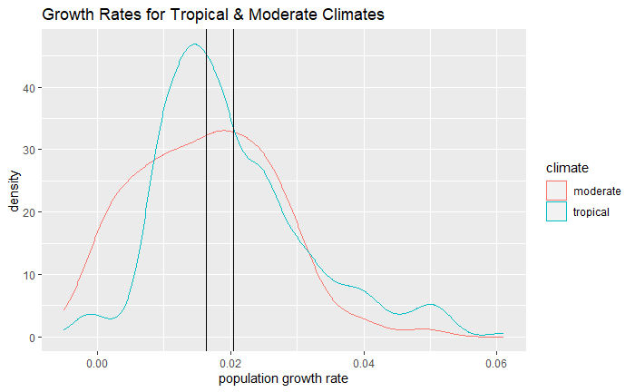

```r
mean_growth <- # create new table containing the avg growth rates for tropical and moderate climates
  climate %>%
  left_join(population) %>%
  na.omit() %>%
  group_by(climate) %>%
  summarise(avg = mean(GrowthRate)) # calculate the mean for each subcategory
climate %>%
  left_join(population) %>%
  na.omit() %>%
  ggplot(aes(x = GrowthRate)) +
  geom_density(aes(colour = climate))  + # create density plot
  geom_vline(aes(xintercept=mean_growth$avg[1])) + # add intercept for tropical locations
  geom_vline(aes(xintercept=mean_growth$avg[2])) + # add intercept for moderate locations
  ggtitle("Growth Rates for Tropical & Moderate Climates") + # rename title
  xlab("population growth rate") # rename x axis
```

- This graph looks at a locations population growth vs its total sunshine hours per year. Based on the line of best fit, each graph shows some amount of positive correlation, meaning more sunshine hours correlates to a higher growth rate (in this data). Moderate climates have a stronger correlation when compared to tropical climates.

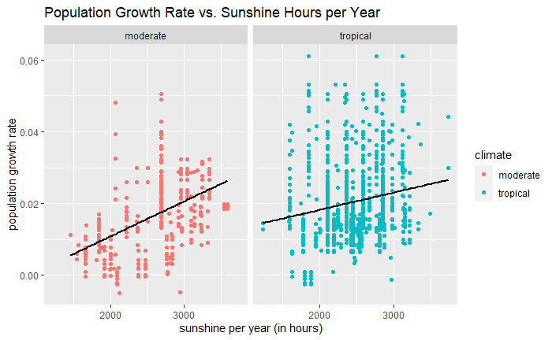

```r
climate %>%
  left_join(population) %>%
  na.omit() %>%
  ggplot(aes(x=Year, y=GrowthRate)) +
  geom_point(aes(color = climate)) +
  facet_wrap(~climate) +
  geom_smooth(method=lm, se=FALSE, color='black') +
  ggtitle("Population Growth Rate vs. Sunshine Hours per Year") +
  xlab("sunshine per year (in hours)") +
  ylab("population growth rate")
```

# Conclusion